# Investigating CO2 Emissions and Renewable Energy Usage

- Show All Code
- Hide All Code
- View Source

Author

Noel Lopez, Patrick George, Riley Svensson, Ningjing Hua

```r
library(tidyverse)
library(broom)
library(knitr)
library(DT)
library(kableExtra)
library(gridExtra)
library(patchwork)
```

[output not shown]

```r
options(scipen = 99999)
energy <- readxl::read_xlsx(here::here("renewable_energy.xlsx"))
co2 <- readxl::read_xlsx(here::here("co2.xlsx"))
```

```r
convert_to_numeric <- function(x) {
  x <- str_replace_all(x, "k", "e3")
  x <- str_replace_all(x, "M", "e6")
  return(as.numeric(x))
}


co2_clean <- co2 |>
  select(country, `1989`:`2017`) |>
  mutate(across(.cols = `1989`:`2017`,
                ~ convert_to_numeric(.))) |>
  pivot_longer(cols = !country,
               names_to = "year",
               values_to = "Total_CO2_Emissions")

energy_clean <- energy |>
  pivot_longer(cols = !country,
               names_to = "year",
               values_to = "Percent_Consumption_Renewable")

joined <- inner_join(co2_clean, energy_clean) |>
  drop_na()

joined |>
  distinct(year) |>
  count()

joined |>
  distinct(country) |>
  count()

master <- joined|>
  rename(Year = year) |>
  group_by(Year) |>
  summarize(`Average Emissions` = mean(`Total_CO2_Emissions`),
            `Average Percent Renewawable`
            = mean(`Percent_Consumption_Renewable`))
```

# 1 Introduction

Climate change is a global challenge jeopardizing humanity’s future. This purpose of this project is to investigate the relationship between CO2 emissions, one of the largest drivers of climate change creating greenhouse gasses, and the use of renewable energy such as solar, wind, or hydroelectric energy. The data to be used in this project incorporates data from two different sources, one measuring total carbon dioxide emissions per country over the years and one measuring proportion of energy use which is renewable over the years. `Total_CO2_Emission` is in 1000 tons of CO2 and `Percent_Consumption_Renewables` is a percentage of total energy use produced by renewable sources per country over the years. Because the data is collected on individual countries over the years, this investigation will primarily focus on the `Average Emissions` as well as the `Average Percent Renewable` of all the countries in a specific year. In the data of which the averages will be investigated, there are 207 distinct countries observed over 29 years. The relationship between `Average Emissions`and `Average Percent Renewable` is hypothesized to be negative whereas humanity used more renewable energy on average there would be less average CO2 emissions. Through this investigation hopefully more information can be learned about climate change and potential solutions to this global problem affecting every organism on planet Earth.

# 2 Materials and Methods

The master data to be used for analysis in this project incorporates the averages for all countries over the years from twodifferent data sets, one measuring the total carbon dioxide emissions, per country over the years and the other measuring the proportion of energy use classified as renewable per country over the years. The data sets were sourced from an online database titled *Gapminder* which has been a reliable provider of data since 2005, in hopes of promoting global sustainability through easily accessible information.

Before analysis, the data had to be properly cleaned and wrangled. The CO2 data set contained values in the form of 25.3k and 4.9M, signaling the units of thousands and millions. The first step in the data cleaning process was to replace these characters with numbers to create a numeric variable which calculations could be performed on. Once the data was of all the same type, the data was then pivoted to be in tidy form and the years of interest (1989 – 2017) were selected. Once pivoted, the data sets were joined by year and country to produce a clean master data set which shall be used for model fitting, plotting, and analysis. A final decision was made to drop all the Na’s in the master set due to a few reasons. The missing values typically occurred in the `Average Percent Renewable` variable across the earlier years measured and usually in countries with smaller populations. Whether these Na’s were included in the data due to lack of observation or for simply not having any renewable energy production or consumption it is unclear. Because the averages are being studied and the Na’s usually occured in smaller countries, there was still a large enough sample size to average over once those observations were dropped. Other forms of imputation were contemplated such as cell-mean imputation but not conducted due to fears of introducing bias to the data.

Linear regression, a method involving predicting the values of one variable, based on another, through producing a straight line minimizing the value for the sum of squared residuals, was used to create and predict a model. All the data cleaning, models, and subsequent analysis was conducted using R code.

```r
datatable((head(master, n = 50)),
          caption = 'Interactive Preview of Data Set')
```

|  | Year | Average Emissions | Average Percent Renewawable |
| --- | --- | --- | --- |
| 1 | 1989 | 114253.345233161 | 32.6773626943005 |
| 2 | 1990 | 113712.105309278 | 32.8455963917526 |
| 3 | 1991 | 110629.208274112 | 32.6329997969543 |
| 4 | 1992 | 111782.975786802 | 32.8483873604061 |
| 5 | 1993 | 111873.784494949 | 33.1323574242424 |
| 6 | 1994 | 113576.862462312 | 33.2096355276382 |
| 7 | 1995 | 116922.812211055 | 32.8995367839196 |
| 8 | 1996 | 117467.412211055 | 32.3735696482412 |
| 9 | 1997 | 116704.434321608 | 32.0921302512563 |
| 10 | 1998 | 118044.385577889 | 32.0770614070352 |

[output cut: 19 more lines]

# 3 Analysis and Discussion of Model

```r
energy_emissions_model <- lm(`Average Emissions` ~
                             `Average Percent Renewawable`,
                             data = master)
summary(energy_emissions_model)
tidy(energy_emissions_model)
```

**Regression Equation:**

$$\hat{y} = 693309.6 - 17770.2 * Average\,Percent\,Renewable$$

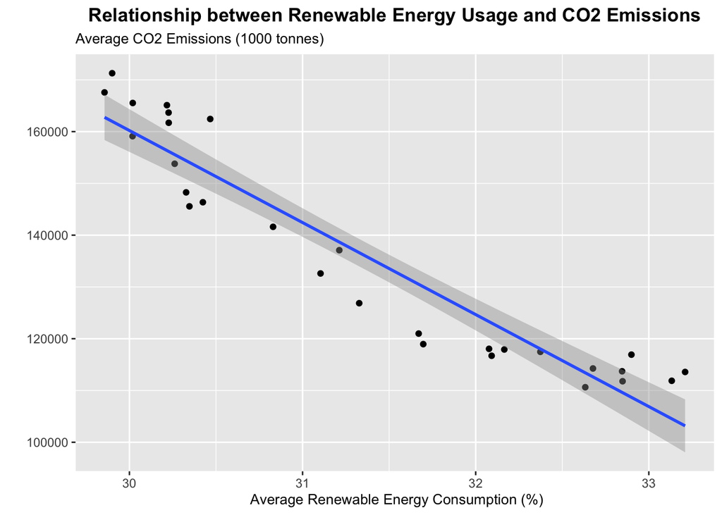

```r
# Plot 1
raw_graph <- master |>
ggplot(aes(x = `Average Percent Renewawable`,
           y = `Average Emissions`)
       ) +
  geom_point() +
  geom_smooth(method = "lm") +
  theme(legend.position = "none") +
  labs(x = " Average Renewable Energy Consumption (%)",
       y = "",
       title = "Relationship between Renewable Energy Usage and CO2 Emissions",
       subtitle = "Average CO2 Emissions (1000 tonnes)") +
  theme(plot.title = element_text(hjust = 0.5, face = 'bold'),
        plot.subtitle = element_text(size = 10),
        axis.title.x = element_text(size = 10))

raw_graph
```

The graph above demonstrates the relationship between `Average Emissions` and `Average Percent Renewable`. The distribution illustrates a negative linear relationship, where the points are relatively close to the plotted regression line with little deviation and noise. There are little to no unusual observations. This illustration is consistent with the hypothesis that as the `Average Percent Renewable` increases the `Average Emissions` decreases at a significant rate.

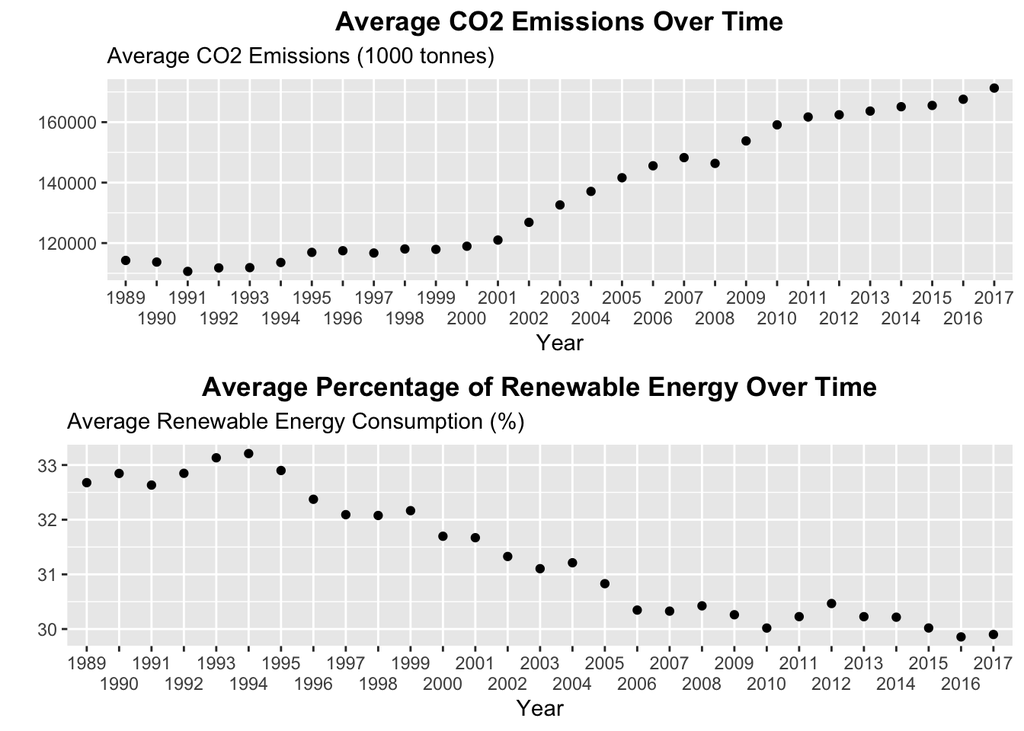

```r
co2_by_year_graph <- master |>
  ggplot(aes(x = Year , y = `Average Emissions`)) +
  geom_point() +
  scale_x_discrete(guide = guide_axis(n.dodge=2)) +
  labs(x = "Year",
       y = "",
       title = "Average CO2 Emissions Over Time",
       subtitle = "Average CO2 Emissions (1000 tonnes)") +
  theme(plot.title = element_text(hjust = 0.5, face = 'bold'))

energy_by_year_graph <- master |>
  ggplot(aes(x = Year, y = `Average Percent Renewawable`)) +
  geom_point() +
   scale_x_discrete(guide = guide_axis(n.dodge=2)) +
    labs(x = "Year",
       y = "",
       title = "Average Percentage of Renewable Energy Over Time",
       subtitle = "Average Renewable Energy Consumption (%)") +
      theme(plot.title = element_text(hjust = 0.5, face = 'bold'))

grid.arrange(co2_by_year_graph, energy_by_year_graph)
```

As shown by the two distributions of `Average Emissions` and `Average Percent Renewable` over time, the relationship follows a negative relationship, but perhaps not as expected. `Average Percent Renewable` is decreasing over the years while `Average Emissions` is increasing which still illustrates a negative relationship. As time goes on it makes sense as to why `Average Emissions` is increasing, because of extreme population growth and growing demand for production but `Average Percent Renewable` has shockingly been declining in recent years. While this likely has something to due to the varying definition of renewable energy, for example whether or not nuclear energy is truly renewable, it is surprising that as technology develops renewable energy use does not. This signifies that humanity needs to increase the renewable energy production and usage on average in order to reduce the carbon footprint and preserve nature for future generations.

**Model Fit:**

```r
energy_emissions_model |>
  augment() |>
  summarize(`Variance of Fitted` = var(.fitted),
            `Variance of Residuals` = var(.resid),
            `Variance of Average CO2 Emissions` = var(`Average Emissions`)) |>
  kable(caption = 'Model Fit',
        digits = 3,
        format.args = list(big.mark = ",")) |>
  kable_styling(bootstrap_options = c('striped', 'bordered'))
```

Model Fit

| Variance of Fitted | Variance of Residuals | Variance of Average CO2 Emissions |
| --- | --- | --- |
| 415,649,404 | 46,532,518 | 462,181,923 |

The proportion of variability in the response values that was accounted for by the model, $R^{2}$, was very large at about at about 89.93 percent. This suggests a good quality model, where a lot, about 89%, of the variation in the response, `Average Emissions` is explained by the explanatory variable, `Average Percent Renewable`. This suggests that a high proportion of variability in response is accounted for by the linear model and there are not many other large factors influencing emissions.

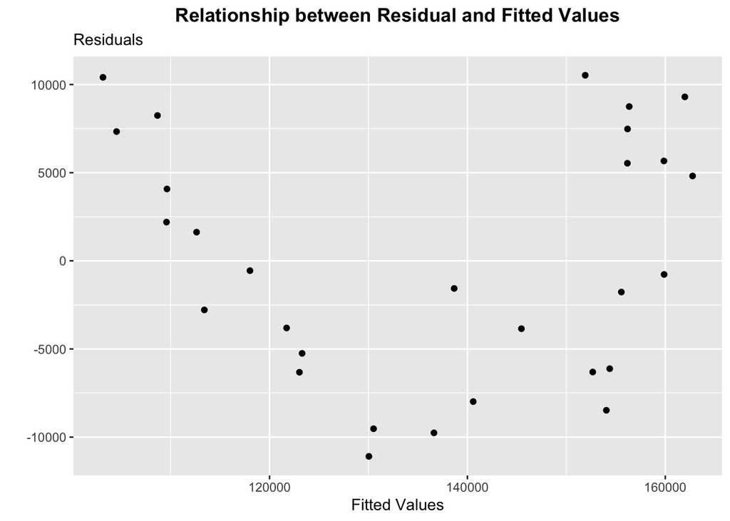

```r
energy_emissions_model |>
  augment() |>
  ggplot(aes(x=.fitted, y = .resid)) +
  geom_point() +
  labs(y = '',
       subtitle = 'Residuals',
       x = 'Fitted Values',
       title = 'Relationship between Residual and Fitted Values') +
  theme(plot.title = element_text(hjust = 0.5, face = 'bold'))
```

**Simulation:**

```r
noise <- function(x, mean = 0, sd){
  x + rnorm(length(x),
            mean,
            sd)
}
```

```r
master_predict <- predict(energy_emissions_model)
master_sigma <- sigma(energy_emissions_model)

sim_response <- tibble(sim_emissions = noise(master_predict,
                                          sd = master_sigma))






raw_graph <- master |>
ggplot(aes(x = `Average Percent Renewawable`,
           y = `Average Emissions`)
       ) +
  geom_point() +
  geom_smooth(method = "lm") +
  theme(legend.position = "none") +
  labs(x = " Avg Renewable energy consumption percentage",
       y = "",
       title = "Relationships between Avg Renewable Energy Consumption and \nAvg CO2 Emissions among different contries",
       subtitle = "Avg CO2 Emissions/1000 tonnes") +
  theme(plot.title.position = "plot")
```

```r
obs_emissions <- master |>
  ggplot(aes(x = `Average Emissions`)) +
  geom_histogram(binwidth = 3000) +
  labs(x = "Observed Emissions",
       y = "",
       subtitle = "Count") +
  theme_bw()


sim_emissions_graph <- sim_response |>
  ggplot(aes(x = sim_emissions)) +
  geom_histogram(binwidth = 3500) +
  labs(x = "Simulated Emissions",
       y = "",
       subtitle = "Count") +
  theme_bw()

obs_emissions + sim_emissions_graph
```

[output not shown]

[output not shown]

```r
sim_data <- master |>
  filter(!is.na(`Average Emissions`),
         !is.na(`Average Percent Renewawable`)
         ) |>
  select(`Average Emissions`, `Average Percent Renewawable`) |>
  bind_cols(sim_response)


raw_graph <- master |>
ggplot(aes(x = `Average Percent Renewawable`,
           y = `Average Emissions`)
       ) +
  geom_point() +

  theme(legend.position = "none") +
  labs(x = " Avg Renewable energy consumption percentage",
       y = "",
       title = "Observed Relationships between Avg Renewable Energy Consumption and \nAvg CO2 Emissions among different contries",
       subtitle = "Avg CO2 Emissions/1000 tonnes") +
  theme(plot.title.position = "plot")

sim_master_graph <- sim_data |>
ggplot(aes(x = `Average Percent Renewawable`,
           y = sim_emissions)
       ) +
  geom_point() +
  theme(legend.position = "none") +
  labs(x = " Avg Renewable energy consumption percentage",
       y = "",
       title = "Simulated Relationships between Avg Renewable Energy Consumption and \nAvg CO2 Emissions among different contries",
       subtitle = "Simulated Avg CO2 Emissions/1000 tonnes") +
  theme(plot.title.position = "plot")

raw_graph + sim_master_graph
```

[output not shown]

[output not shown]

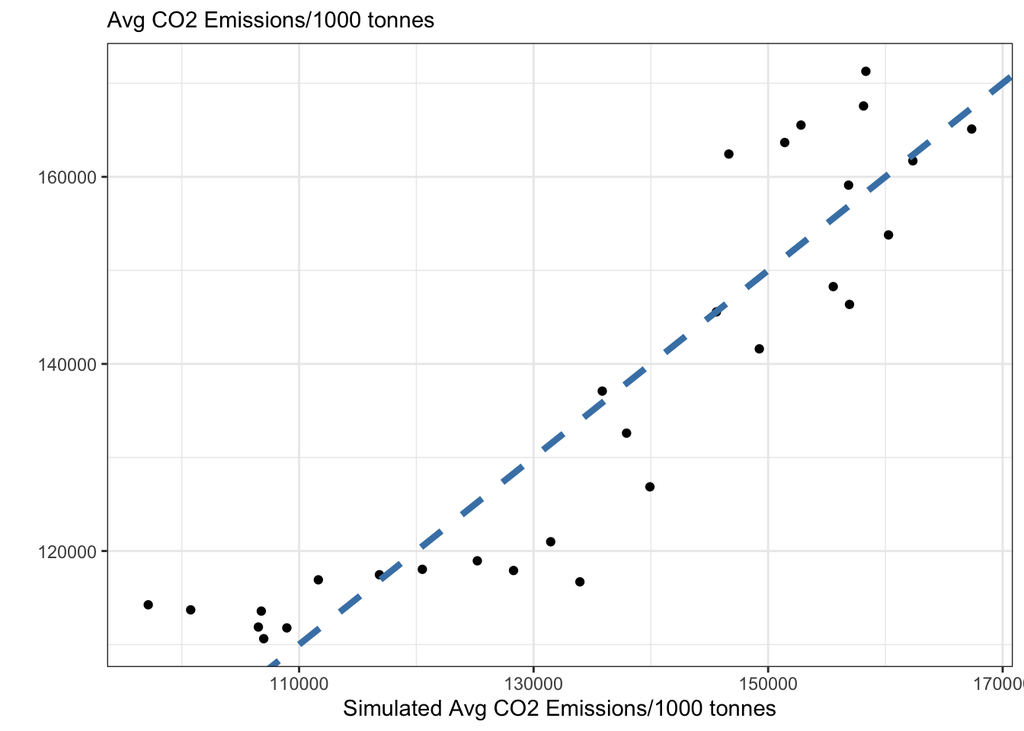

```r
# Check the similarity between the simulated data and observed data
sim_data |>
  ggplot(aes(x = sim_emissions,
             y = `Average Emissions`)
         ) +
  geom_point() +
   labs(x = "Simulated Avg CO2 Emissions/1000 tonnes",
        y = "",
        subtitle = "Avg CO2 Emissions/1000 tonnes" ) +
  geom_abline(slope = 1,
              intercept = 0,
              color = "steelblue",
              linetype = "dashed",
              lwd = 1.5) +
  theme_bw()
```

```r
# check how the simulated data fit the observed data, especially the R square.
lm(`Average Emissions` ~ sim_emissions,
   data = sim_data
   ) |>
  glance()
```

```
# A tibble: 1 × 12
  r.squared adj.r.squa…¹ sigma stati…²  p.value    df logLik   AIC   BIC devia…³
      <dbl>        <dbl> <dbl>   <dbl>    <dbl> <dbl>  <dbl> <dbl> <dbl>   <dbl>
1     0.821        0.814 9261.    124. 1.36e-11     1  -305.  616.  620.  2.32e9
# … with 2 more variables: df.residual <int>, nobs <int>, and abbreviated
#   variable names ¹adj.r.squared, ²statistic, ³deviance
```

```r
# get the R squared for the simulated data fit for observed data.
sim_r2 <- lm(`Average Emissions` ~ sim_emissions,
             data = sim_data
             ) |>
  glance() |>
  select(r.squared) |>
  pull()
sim_r2
```

```
[1] 0.8210543
```

```r
# Created 1000 simulated dataset
nsims <- 1000
sims <- map_dfc(.x = 1:nsims,
                .f = ~ tibble(sim = noise(master_predict,
                                          sd = master_sigma)
                              )
                )

head(sims)
```

```
# A tibble: 6 × 1,000
  sim...1 sim...2 sim...3 sim...4 sim...5 sim...6 sim...7 sim...8 sim...9
    <dbl>   <dbl>   <dbl>   <dbl>   <dbl>   <dbl>   <dbl>   <dbl>   <dbl>
1 124107. 111736. 112793. 119910. 103948. 110044. 113407. 102446. 119776.
2 123417. 106374. 108435. 103987. 101951. 110609. 119170. 115403. 108647.
3 117173. 120500. 115167. 114152. 111252. 106961. 109460. 107555. 111107.
4 110998. 116846. 113926. 111626. 112144. 115220. 115971. 109659. 101394.
5 111051. 100945.  98565.  98743. 108427. 102417. 117136. 105620.  98257.
6 107355.  89757. 108215. 105845.  87102. 105102.  93000. 100241.  98826.
# … with 991 more variables: sim...10 <dbl>, sim...11 <dbl>, sim...12 <dbl>,
#   sim...13 <dbl>, sim...14 <dbl>, sim...15 <dbl>, sim...16 <dbl>,
#   sim...17 <dbl>, sim...18 <dbl>, sim...19 <dbl>, sim...20 <dbl>,
#   sim...21 <dbl>, sim...22 <dbl>, sim...23 <dbl>, sim...24 <dbl>,
#   sim...25 <dbl>, sim...26 <dbl>, sim...27 <dbl>, sim...28 <dbl>,
#   sim...29 <dbl>, sim...30 <dbl>, sim...31 <dbl>, sim...32 <dbl>,
#   sim...33 <dbl>, sim...34 <dbl>, sim...35 <dbl>, sim...36 <dbl>, …
```

```r
# clean the colnames
colnames(sims) <- colnames(sims) |>
  str_replace(pattern = "\\.\\.\\.",
                  replace = "_")
head(sims)
```

```
# A tibble: 6 × 1,000
    sim_1   sim_2  sim_3  sim_4  sim_5  sim_6  sim_7  sim_8  sim_9 sim_10 sim_11
    <dbl>   <dbl>  <dbl>  <dbl>  <dbl>  <dbl>  <dbl>  <dbl>  <dbl>  <dbl>  <dbl>
1 124107. 111736. 1.13e5 1.20e5 1.04e5 1.10e5 1.13e5 1.02e5 1.20e5 1.18e5 1.23e5
2 123417. 106374. 1.08e5 1.04e5 1.02e5 1.11e5 1.19e5 1.15e5 1.09e5 1.12e5 1.14e5
3 117173. 120500. 1.15e5 1.14e5 1.11e5 1.07e5 1.09e5 1.08e5 1.11e5 1.16e5 1.14e5
4 110998. 116846. 1.14e5 1.12e5 1.12e5 1.15e5 1.16e5 1.10e5 1.01e5 1.13e5 1.27e5
5 111051. 100945. 9.86e4 9.87e4 1.08e5 1.02e5 1.17e5 1.06e5 9.83e4 1.13e5 1.02e5
6 107355.  89757. 1.08e5 1.06e5 8.71e4 1.05e5 9.30e4 1.00e5 9.88e4 1.08e5 1.11e5
# … with 989 more variables: sim_12 <dbl>, sim_13 <dbl>, sim_14 <dbl>,
#   sim_15 <dbl>, sim_16 <dbl>, sim_17 <dbl>, sim_18 <dbl>, sim_19 <dbl>,
#   sim_20 <dbl>, sim_21 <dbl>, sim_22 <dbl>, sim_23 <dbl>, sim_24 <dbl>,
#   sim_25 <dbl>, sim_26 <dbl>, sim_27 <dbl>, sim_28 <dbl>, sim_29 <dbl>,
#   sim_30 <dbl>, sim_31 <dbl>, sim_32 <dbl>, sim_33 <dbl>, sim_34 <dbl>,
#   sim_35 <dbl>, sim_36 <dbl>, sim_37 <dbl>, sim_38 <dbl>, sim_39 <dbl>,
#   sim_40 <dbl>, sim_41 <dbl>, sim_42 <dbl>, sim_43 <dbl>, sim_44 <dbl>, …
```

```r
# bind 1000 simulated dataset and the observed dataset together
sims <- master |>
  filter(!is.na(`Average Emissions`),
         !is.na(`Average Percent Renewawable`)) |>
  select(`Average Emissions`) |>
  bind_cols(sims)

head(sims)
```

```
# A tibble: 6 × 1,001
  Averag…¹  sim_1  sim_2  sim_3  sim_4  sim_5  sim_6  sim_7  sim_8  sim_9 sim_10
     <dbl>  <dbl>  <dbl>  <dbl>  <dbl>  <dbl>  <dbl>  <dbl>  <dbl>  <dbl>  <dbl>
1  114253. 1.24e5 1.12e5 1.13e5 1.20e5 1.04e5 1.10e5 1.13e5 1.02e5 1.20e5 1.18e5
2  113712. 1.23e5 1.06e5 1.08e5 1.04e5 1.02e5 1.11e5 1.19e5 1.15e5 1.09e5 1.12e5
3  110629. 1.17e5 1.20e5 1.15e5 1.14e5 1.11e5 1.07e5 1.09e5 1.08e5 1.11e5 1.16e5
4  111783. 1.11e5 1.17e5 1.14e5 1.12e5 1.12e5 1.15e5 1.16e5 1.10e5 1.01e5 1.13e5
5  111874. 1.11e5 1.01e5 9.86e4 9.87e4 1.08e5 1.02e5 1.17e5 1.06e5 9.83e4 1.13e5
6  113577. 1.07e5 8.98e4 1.08e5 1.06e5 8.71e4 1.05e5 9.30e4 1.00e5 9.88e4 1.08e5
# … with 990 more variables: sim_11 <dbl>, sim_12 <dbl>, sim_13 <dbl>,
#   sim_14 <dbl>, sim_15 <dbl>, sim_16 <dbl>, sim_17 <dbl>, sim_18 <dbl>,
#   sim_19 <dbl>, sim_20 <dbl>, sim_21 <dbl>, sim_22 <dbl>, sim_23 <dbl>,
#   sim_24 <dbl>, sim_25 <dbl>, sim_26 <dbl>, sim_27 <dbl>, sim_28 <dbl>,
#   sim_29 <dbl>, sim_30 <dbl>, sim_31 <dbl>, sim_32 <dbl>, sim_33 <dbl>,
#   sim_34 <dbl>, sim_35 <dbl>, sim_36 <dbl>, sim_37 <dbl>, sim_38 <dbl>,
#   sim_39 <dbl>, sim_40 <dbl>, sim_41 <dbl>, sim_42 <dbl>, sim_43 <dbl>, …
```

```r
# mapping to get 1000 simulated R squared.
sim_r_sq <- sims |>
  map(~ lm(`Average Emissions` ~ .x, data = sims)) |>
  map(glance) |>
  map_dbl(~ .x$r.squared)

head(sim_r_sq)
```

```
Average Emissions             sim_1             sim_2             sim_3
        1.0000000         0.8562973         0.7550128         0.8842073
            sim_4             sim_5
        0.8681675         0.7613779
```

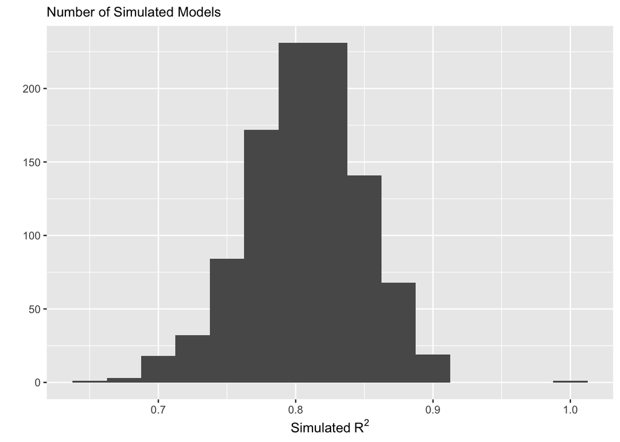

```r
# to see the distribution of the 1000 simulated R square.
tibble(sims = sim_r_sq) |>
  ggplot(aes(x = sims)) +
  geom_histogram(binwidth = 0.025) +
  labs(x = expression("Simulated"~ R^2),
       y = "",
       subtitle = "Number of Simulated Models")
```

```r
#The distribution of these values will tell if our assumed model does a good job of producing data similar to what was observed. If the model produces data similar to what was observed, we would expect values near 1.
# Our model is R square is around 0.8.
```

# 4 References

https://www.gapminder.org/data/